# lubridate

Даты без боли

Калакуцкий Аркадий

Младший технический аналитик

JetBrains

15.04.2017

# История первая

### Про активных пользователей

Есть вот такие данные:

```r
user.activities <- read.csv("data/user_activities.csv")
head(user.activities)
```

```
##   user.id activity.dates
## 1     386     2010-06-26
## 2     891     2010-07-10
## 3     633     2010-07-12
## 4     732     2010-08-06
## 5     127     2010-08-27
## 6     127     2010-09-02
```

Нужно построить график активности пользователей по месяцам.

# История первая

Округлим даты к началу месяца

*Без lubridate*

```r
as.Date(format(as.Date(user.activities$activity.dates), "%Y-%m-01")) %>% head
```

```
## [1] "2010-06-01" "2010-07-01" "2010-07-01" "2010-08-01" "2010-08-01"
## [6] "2010-09-01"
```

Среднее время исполнения:

```
## [1] 0.1274
```

# История первая

Округлим даты к началу месяца

*С Lubridate*

```r
floor_date(as.Date(user.activities$activity.dates), "month") %>% head
```

```
## [1] "2010-06-01" "2010-07-01" "2010-07-01" "2010-08-01" "2010-08-01"
## [6] "2010-09-01"
```

Среднее время исполнения:

```
## [1] 0.08404
```

# История первая

Найдем месяц первой и последней активности для каждого пользователя

```r
user.activities.months <- user.activities %>%
  mutate(activity.month = floor_date(as.Date(activity.dates), "month")) %>%
  group_by(user.id) %>%
  summarise(first.month = min(activity.month),
            last.month = max(activity.month))
head(user.activities.months)
```

```
## # A tibble: 6 x 3
##   user.id first.month last.month
##     <int>      <date>     <date>
## 1       1  2012-03-01 2016-12-01
## 2       2  2016-02-01 2016-02-01
## 3       3  2013-06-01 2016-12-01
## 4       4  2012-07-01 2016-09-01
## 5       5  2013-02-01 2016-12-01
## 6       6  2012-09-01 2016-12-01
```

# История первая

Теперь для к дате последней активности добавим год.

Как это делать без lubridate?

# История первая

Теперь для к дате последней активности добавим год.

Как это делать с lubridate?

```r
user.activities.months$last.month %>% head
```

```
## [1] "2016-12-01" "2016-02-01" "2016-12-01" "2016-09-01" "2016-12-01"
## [6] "2016-12-01"
```

```r
(user.activities.months$last.month + years(1)) %>% head
```

```
## [1] "2017-12-01" "2017-02-01" "2017-12-01" "2017-09-01" "2017-12-01"
## [6] "2017-12-01"
```

# Period

```r
date <- as.Date("2016-02-12")
date + c(years(1), months(1), days(1))
```

```
## [1] "2017-02-12" "2016-03-12" "2016-02-13"
```

```r
date + (years(1)*2 + months(1))
```

```
## [1] "2018-03-12"
```

# Period

Что получится в результате?

```r
as.Date("2016-02-29") + years(1)
as.Date("2016-01-31") + months(1)
```

# Period

```r
as.Date("2016-02-29") + years(1)
```

```
## [1] NA
```

```r
as.Date("2016-01-31") + months(1)
```

```
## [1] NA
```

# Period

Если мы имели в виду что-то другое:

```r
as.Date("2016-02-29") %m+% years(1)
```

```
## [1] "2017-02-28"
```

```r
as.Date("2016-01-31") %m+% months(1)
```

```
## [1] "2016-02-29"
```

# История первая

Количество активных пользователей по месяцам:

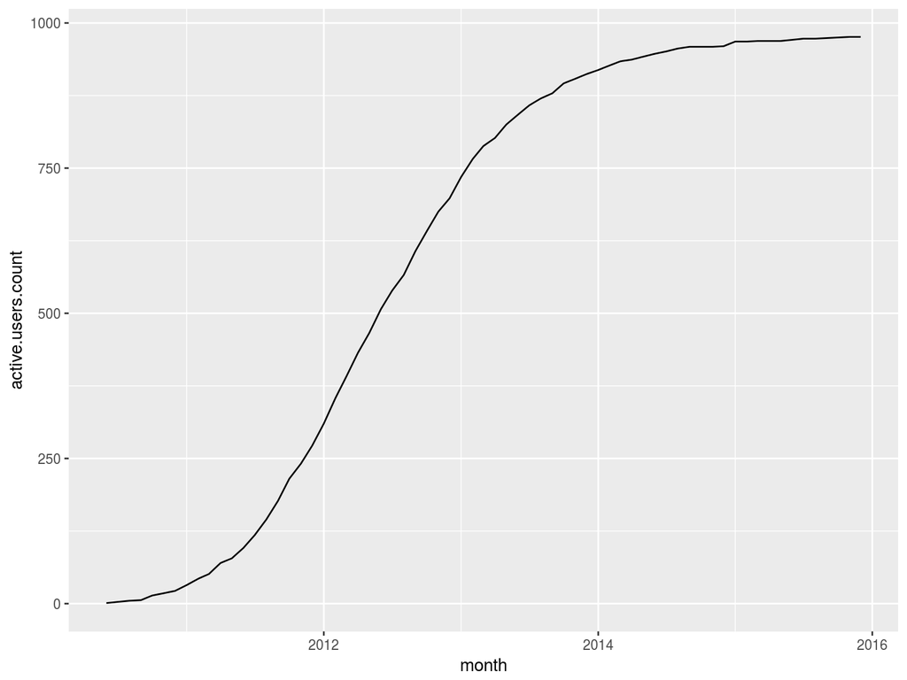

# История вторая

### Про плохую выгрузку

Что делать с такими данными?

```r
bad.dates <- read.csv("data/bad_formats.csv", stringsAsFactors = FALSE)$x
head(bad.dates)
```

```
## [1] "2012-01-05 17:48"    "2012-01-09 22:14:57" "2012-01-11 13:45:27"
## [4] "2012-01-12 14:17:37" "2012-01-20 12:26:08" "2012-01-23 09:00"
```

# История вторая

```r
parse_date_time(bad.dates,
                orders = c("%Y-%m-%d %H:%M:%S",
                           "%Y-%m-%d %H:%M",
                           "%Y-%m-%d")) %>% head
```

```
## [1] "2012-01-05 17:48:00 UTC" "2012-01-09 22:14:57 UTC"
## [3] "2012-01-11 13:45:27 UTC" "2012-01-12 14:17:37 UTC"
## [5] "2012-01-20 12:26:08 UTC" "2012-01-23 09:00:00 UTC"
```

# История вторая

```r
parse_date_time(bad.dates,
                orders = c("ymd",
                           "ymdHM",
                           "ymdHMS")) %>% head
```

```
## [1] "2012-01-05 17:48:00 UTC" "2012-01-09 22:14:57 UTC"
## [3] "2012-01-11 13:45:27 UTC" "2012-01-12 14:17:37 UTC"
## [5] "2012-01-20 12:26:08 UTC" "2012-01-23 09:00:00 UTC"
```

# Cемейство `ymd`

`ymd`, `dmy`, `ydm`, `mdy`, `hm`, `ms`, `hms`, `ymd_hms`

```r
ymd('20120101','120101','12-01-01','12asdf1dfdf1')
```

```
## [1] "2012-01-01" "2012-01-01" "2012-01-01" "2012-01-01"
```

# История третья

### Про секунды

Есть измерения длительности события при разных условиях:

```r
seconds <- read.csv("data/seconds.csv")
seconds %>% head
```

```
##   condition     time
## 1         A 00:19:12
## 2         A 00:16:24
## 3         A 00:16:46
## 4         A 00:04:49
## 5         A 00:05:37
## 6         A 00:13:34
```

Нужно проверить гипотезу о том, что среднее время при условиях `А` меньше.

# История третья

Как из `"00:01:41"` получить секунды?

# История третья

Как из `"00:01:41"` получить секунды?

```r
as.integer(as.duration(hms(seconds$time))) %>% head
```

```
## [1] 1152  984 1006  289  337  814
```

# Отрезки времени

### Period

### Duration

### Interval

# Duration

```r
dmicroseconds(1)
```

```
## [1] "1e-06s"
```

```r
dseconds(1)
```

```
## [1] "1s"
```

```r
ddays(1)
```

```
## [1] "86400s (~1 days)"
```

```r
dyears(1)
```

```
## [1] "31536000s (~52.14 weeks)"
```

# Interval

```r
interval("2012-01-01","2012-02-01")
```

```
## [1] 2012-01-01 UTC--2012-02-01 UTC
```

# История третья

Чем все закончилось?

```r
seconds$seconds <- as.integer(as.duration(hms(seconds$time)))
seconds.a <- seconds %>% filter(condition == 'A') %>% select(seconds) %>% unlist
seconds.b <- seconds %>% filter(condition == 'B') %>% select(seconds) %>% unlist
t.test(seconds.a, seconds.b, alternative = "less")
```

```
##
##  Welch Two Sample t-test
##
## data:  seconds.a and seconds.b
## t = -16.033, df = 145.77, p-value < 2.2e-16
## alternative hypothesis: true difference in means is less than 0
## 95 percent confidence interval:
##       -Inf -1818.092
## sample estimates:
## mean of x mean of y
##    919.23   2946.65
```

# На этом все

О чем я не рассказал:

- о работе с часовыми поясами и летним временем;
- о манипулировании с элементами дат;
- guess_format и parse_date_time2;
- …

# Где узнать больше?

[Do more with dates and times in R with lubridate](https://cran.r-project.org/web/packages/lubridate/vignettes/lubridate.html)

[Dates and Times Made Easy with lubridate](https://www.jstatsoft.org/article/view/v040i03/v40i03.pdf)

[Документация](https://cran.r-project.org/web/packages/lubridate/lubridate.pdf)

[Эта презентация с кодом и данными](https://github.com/testlnord/lubridate_presentation)

# Спасибо за внимание

Вопросы?